# 465 Metric Examples

```r
library(Lahman)
library(tidymodels)
library(tidyverse)
library(janitor)
tidymodels_prefer()
```

# Precision-Recall Curves

From the presentation by Luke Hamm, Andrew Howe, Noah Husted. Adapted for `tidymodels` and `yardstick` by your professor.

```r
# Import data
data <- Batting |>
  filter(yearID >= 1960, AB >= 200) |>
  mutate(HR30 = as.factor(ifelse(HR >= 30, 1, 0)))

# Create training and test sets
set.seed(12345)

split <- initial_split(data, prop = 0.8) # should be initial_time_split, but will update later

trainData <- training(split)
testData <- testing(split)
folds <- vfold_cv(trainData, v = 10, repeats = 5)


# preprocessing steps
rec <- recipe(HR30 ~ AB + H + RBI + BB + SO + SB, data = trainData) |>
  step_naomit(all_predictors()) |> # to omit missing rows
  step_normalize(all_numeric_predictors())
```

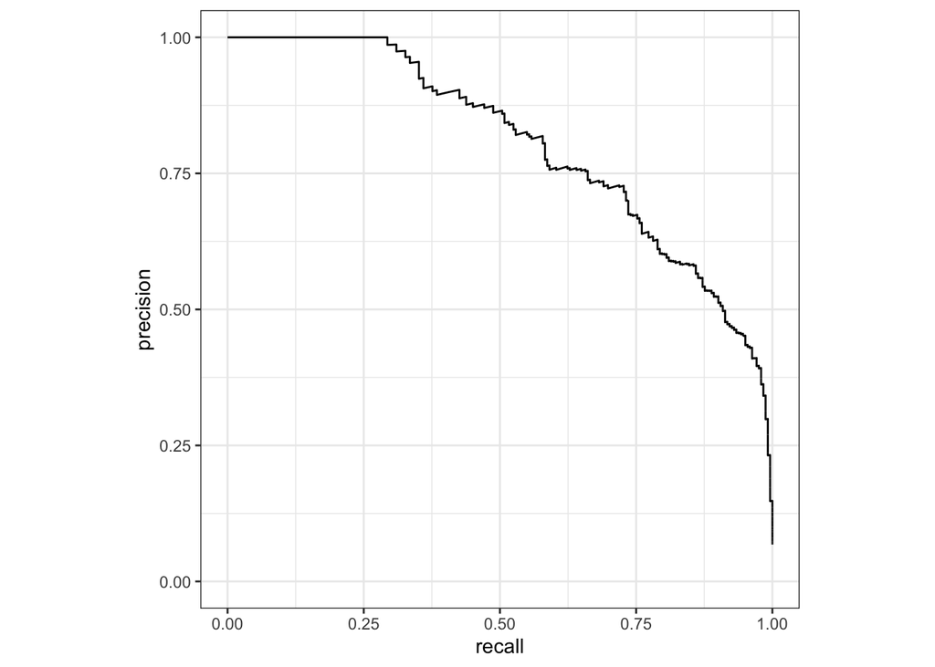

```r
# simple way, no tuning
model <- logistic_reg() |>
  set_engine("glm") |>
  set_mode("classification")

hr_wkflow <- workflow() |>
  add_model(model) |>
  add_recipe(rec)

hr_pred <- hr_wkflow |>
  fit(data = trainData) |>
  augment(new_data = testData)

# use the `pr_curve` function from `yardstick`
# the event of interest is HR30 = 1, which is second
pr_curve_info <- pr_curve(hr_pred, .pred_1, truth = HR30, event_level = "second")
autoplot(pr_curve_info) # could also use ggplot, as below
```

```r
# gives the area under the PR curve, values close to 1 are better
pr_auc(hr_pred, .pred_1, truth = HR30, event_level = "second")
```

```
## # A tibble: 1 × 3
##   .metric .estimator .estimate
##   <chr>   <chr>          <dbl>
## 1 pr_auc  binary         0.804
```

```r
# ggplot(pr_curve_info, aes(x=recall, y=precision)) +
#   geom_path() +
#   coord_equal()
```

```r
pr_curve_info |>
  filter(precision <.81, precision > .80)
```

```
## # A tibble: 4 × 3
##   .threshold recall precision
##        <dbl>  <dbl>     <dbl>
## 1      0.572  0.579     0.809
## 2      0.571  0.579     0.805
## 3      0.554  0.583     0.806
## 4      0.549  0.583     0.801
```

Alternatively, the `threshold_perf` function gives us the values of a metric over different thresholds:

```r
library(probably)
threshold_perf(
  hr_pred,
  truth=HR30,
  estimate=.pred_1,
  thresholds = seq(0.2, 0.8, by = 0.1),
  metrics = metric_set(f_meas, precision, recall),
  event_level = "second"
  )
```

```
## # A tibble: 21 × 4
##    .threshold .metric   .estimator .estimate
##         <dbl> <chr>     <chr>          <dbl>
##  1        0.2 f_meas    binary         0.684
##  2        0.3 f_meas    binary         0.706
##  3        0.4 f_meas    binary         0.707
##  4        0.5 f_meas    binary         0.683
##  5        0.6 f_meas    binary         0.658
##  6        0.7 f_meas    binary         0.619
##  7        0.8 f_meas    binary         0.512
##  8        0.2 precision binary         0.590
##  9        0.3 precision binary         0.672
## 10        0.4 precision binary         0.733
## # ℹ 11 more rows
```

# Multi-class Sensitivity and Specificity

Luke Johnsen, Jacob Turrubiartes, Joshua Winnes

```r
Diabetes <- read.csv("diabetes.csv") |> mutate(group = as.factor(group))
```

## Splits and Recipe

```r
set.seed(2023)
diab_split <- Diabetes %>%
  initial_split(
    prop = 0.7,
    strata = group
  )
diab_test <- testing(diab_split)
diab_train <- training(diab_split)

recipe <- recipe(group ~ ., data = diab_train) %>%
  step_normalize(all_predictors())
```

```r
library(discrim)
lda_model <- discrim_linear() %>%
  set_engine("MASS") %>%
  set_mode("classification")
```

## Get Results

```r
lda_workflow <- workflow() %>%
  add_model(lda_model) %>%
  add_recipe(recipe)

lda_fit <- lda_workflow %>%
  fit(data= diab_train)

predictions <- predict(lda_fit, new_data = diab_test)

results <- diab_test %>%
  select(group) %>%
  bind_cols(predictions)
```

## Calculate Metrics

```r
sensitivity(results, group, .pred_class, estimator = "macro")
```

```
## # A tibble: 1 × 3
##   .metric     .estimator .estimate
##   <chr>       <chr>          <dbl>
## 1 sensitivity macro          0.952
```

```r
sensitivity(results, group, .pred_class, estimator = "macro_weighted")
```

```
## # A tibble: 1 × 3
##   .metric     .estimator     .estimate
##   <chr>       <chr>              <dbl>
## 1 sensitivity macro_weighted     0.955
```

```r
sensitivity(results, group, .pred_class, estimator = "micro")
```

```
## # A tibble: 1 × 3
##   .metric     .estimator .estimate
##   <chr>       <chr>          <dbl>
## 1 sensitivity micro          0.955
```

```r
specificity(results, group, .pred_class, estimator = "macro")
```

```
## # A tibble: 1 × 3
##   .metric     .estimator .estimate
##   <chr>       <chr>          <dbl>
## 1 specificity macro          0.974
```

```r
specificity(results, group, .pred_class, estimator = "macro_weighted")
```

```
## # A tibble: 1 × 3
##   .metric     .estimator     .estimate
##   <chr>       <chr>              <dbl>
## 1 specificity macro_weighted     0.968
```

```r
specificity(results, group, .pred_class, estimator = "micro")
```

```
## # A tibble: 1 × 3
##   .metric     .estimator .estimate
##   <chr>       <chr>          <dbl>
## 1 specificity micro          0.977
```

# ROC/AUC

Audrey Fitzekam, Daniel Olson

## Example 1

```r
patients <- read.csv("breast-cancer.csv") |>
  clean_names() |>
  mutate(class = as.factor(class))

# Data splitting
set.seed(42)
patients_split <- initial_split(patients, prop = 0.80, strata = class)
patients_train <- training(patients_split)
patients_test <- testing(patients_split)
patients_folds <- vfold_cv(patients_train, v=10)

# Model, recipe, and workflow
logreg_model <- logistic_reg()

logreg_recipe <- recipe(class ~ ., data=patients_train) |>
  update_role(id, new_role="id")

logreg_wf <- workflow(logreg_recipe, logreg_model)
```

ROC/AUC is one of many metrics that can be computed using `fit_resamples`.

```r
logreg_wf |>
  fit_resamples(resamples = patients_folds, metrics = metric_set(roc_auc)) |>
  collect_metrics() # ROC/AUC is also one of the default metrics if `metrics` is unspecified
```

```
## # A tibble: 1 × 6
##   .metric .estimator  mean     n std_err .config
##   <chr>   <chr>      <dbl> <int>   <dbl> <chr>
## 1 roc_auc binary     0.994    10 0.00354 Preprocessor1_Model1
```

We can also calculate the ROC/AUC of a fitted model with `roc_auc()`.

```r
logreg_results <- logreg_wf |>
  fit(data = patients_train) |>
  augment(new_data = patients_test)

roc_auc(logreg_results, truth = class, .pred_1, event_level = "second")
```

```
## # A tibble: 1 × 3
##   .metric .estimator .estimate
##   <chr>   <chr>          <dbl>
## 1 roc_auc binary         0.999
```

Let’s take a look at the ROC curve itself, using `roc_curve()` and `autoplot()`. Note that the arguments to `roc_curve()` and `roc_auc()` are exactly the same.

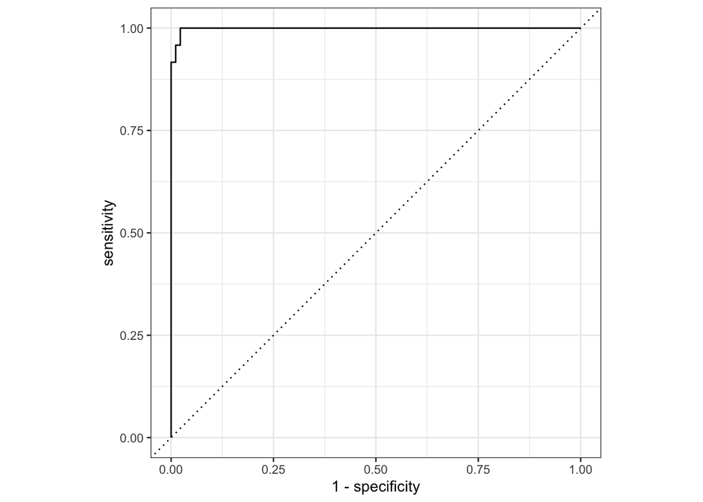

```r
roc_curve(logreg_results, truth = class, .pred_1, event_level = "second") |>
  autoplot()
```

This ROC curve hugs the top left and has an AUC close to 1, which is very good. Now let’s look at a different example where the ROC/AUC isn’t quite as high.

## Example 2

```r
titanic <- read_csv("titanic.csv") |>
  clean_names() |>
  mutate(survived = as.factor(survived), sex = as.factor(sex))

# Data splitting
set.seed(2025)
titanic_split <- initial_split(titanic, prop = 0.80, strata = survived)
titanic_train <- training(titanic_split)
titanic_test  <- testing(titanic_split)
titanic_folds <- vfold_cv(titanic_train, v=10, strata = survived)

# Recipe
titanic_rec <- recipe(survived ~ ., data = titanic_train) |>
  update_role(name, new_role = "id") |>
  step_normalize(all_numeric_predictors()) |>
  step_dummy(sex)

# Model and workflow
titanic_knn <- nearest_neighbor(neighbors = 5, weight_func = "gaussian") |>
  set_mode("classification")

titanic_wf <- workflow(titanic_rec, titanic_knn)

# Fitting
titanic_results <- titanic_wf |>
  fit(titanic_train) |>
  augment(new_data = titanic_test)
```

```r
titanic_results |> roc_auc(truth = survived, .pred_1, event_level = "second")
```

```
## # A tibble: 1 × 3
##   .metric .estimator .estimate
##   <chr>   <chr>          <dbl>
## 1 roc_auc binary         0.853
```

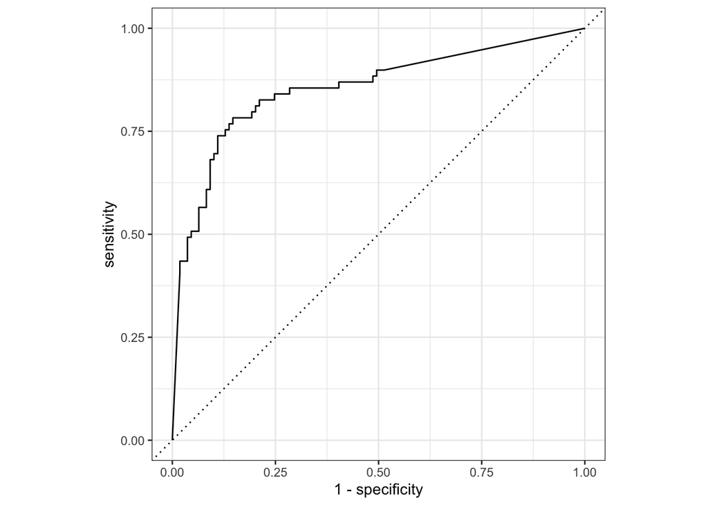

```r
titanic_results |>
  roc_curve(truth = survived, .pred_1, event_level = "second") |>
  autoplot()
```

# F measure

Kevin Yuvaraj, et al

This example has the same set up as above, so I didn’t reprint the code. Compare the f1 scores to the two examples above.

Very high F1 score, since precision and recall are both high:

```r
f1_score_cancer <- f_meas(logreg_results, truth = class, estimate = .pred_class)

print(f1_score_cancer)
```

```
## # A tibble: 1 × 3
##   .metric .estimator .estimate
##   <chr>   <chr>          <dbl>
## 1 f_meas  binary         0.978
```

An F1-score of 0.828 means the knn-model has a good balance between precision and recall. Applying this to the titanic dataset, it means the model predicts Titanic survival pretty well since it minimizing false positives and false negatives.

```r
f1_score_titanic <- f_meas(titanic_results, truth = survived, estimate = .pred_class)

print(f1_score_titanic)
```

```
## # A tibble: 1 × 3
##   .metric .estimator .estimate
##   <chr>   <chr>          <dbl>
## 1 f_meas  binary         0.829
```